# Meu Notebook metalinguístico

# 1 **Bem-vindo(a)!**

[figure not shown]

Minha Foto

**Equação de Maxwell (Lei de Ampère-Maxwell)**
$$∇×B=μ0J+μ_0ε_0(∂t/∂E)$$

Olá! Eu sou Francisco de Assis Pereira Neto, estudante de Direito pela Universidade Federal de Lavras em Minas Gerais. Sou amante da literatura, filosofia, tecnologia, e tenho um grande interesse em Python, SQL/Database, Data Science e Django. Esta página é uma pequena introdução sobre mim.

## 1.1 **Curiosidades e Habilidades**

### 1.1.1 **Python**

- Gosto de explorar novas bibliotecas e automatizar tarefas.

### 1.1.2 **SQL/Database**

- Adoro manipular e consultar bancos de dados.

### 1.1.3 **Data Science**

- Sou experiente em análise e ciência de dados, sempre analisando dados e criando visualizações interessantes.
- Veja um gráfico simples:

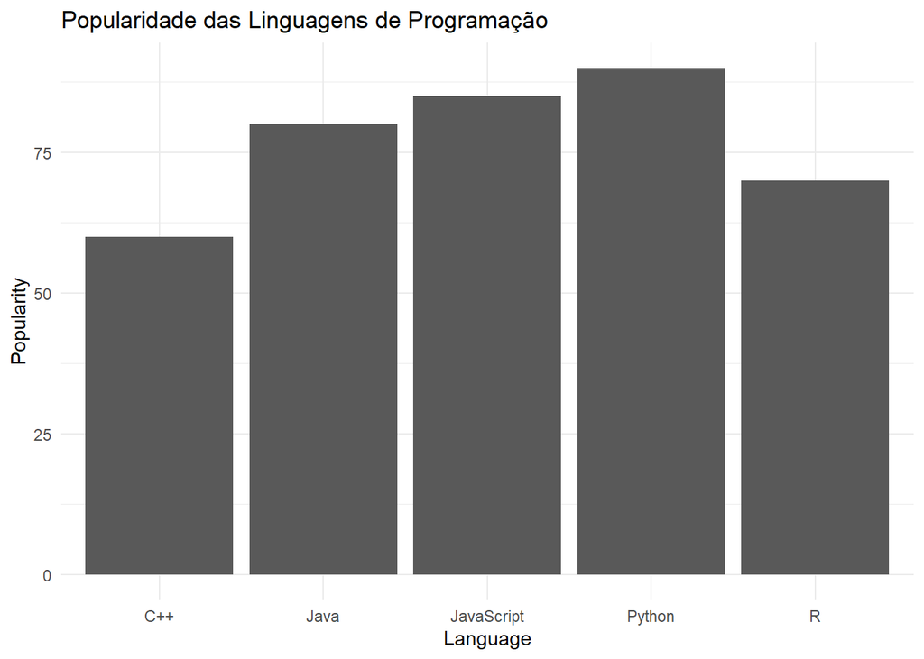

```r
library(ggplot2)
data <- data.frame(
  Language = c("R", "Python", "Java", "C++", "JavaScript"),
  Popularity = c(70, 90, 80, 60, 85)
)

ggplot(data, aes(x = Language, y = Popularity)) +
  geom_bar(stat = "identity") +
  theme_minimal() +
  ggtitle("Popularidade das Linguagens de Programação")
```

### 1.1.4 **Django**

- Trabalho com desenvolvimento de aplicações web usando Django.

## 1.2 **Minhas Paixões**

- **Literatura:** Sempre tenho um livro na cabeceira. Alguns dos meus autores favoritos incluem Dostoiévski e Gabriel García Márquez.
- **Filosofia:** Adoro discutir e refletir sobre questões filosóficas. Nietzsche e Kant são algumas das minhas influências.
- **Tecnologia:** Gosto de estar atualizado com as últimas inovações tecnológicas e explorar como elas podem ser aplicadas em diferentes áreas.

## 1.3 **Uma Piada para Alegrar o Dia**

Por que os programadores preferem o escuro? Porque a luz atrapalha o código!

## 1.4 **Contato**

Se quiser bater um papo ou trocar ideias, você pode me encontrar nos seguintes lugares:

- [TryHackMe](https://tryhackme.com/p/francisconetodata)
- [GitHub](https://github.com/francisconetodata)
- [LinkedIn](https://www.linkedin.com/in/francisconetodata/)

Ou enviar um e-mail para francisconetodata@gmail.com.

## 1.5 **Até Mais!**

Obrigado por visitar minha página divertida! Espero que tenha gostado e volte sempre!